# DharmaResearch Equities

Artha Finance SA

## Etude de l’apport pour DEQ d’un investissement dans Q-Capital

### Recherche d’amélioration des ratios Sharpe et Sortino

##### Remarques

La contrainte Ucit actuelle est de 10% de fonds tiers au maximum dans DEQ La stratégie QasCash n’est de ce fait pas réalisable dans certaines périodes

Le coût du hedge en Euro ainsi que le pro-forma de Q sont des estimations théoriques

Le pro-forma février 2018 et la NAV de la tranche Euro de Q seront ajoutés à cette étude prochainement

La stratégie DEQex est ex-Cash ex Fees. Nous ne pouvons malheureusement pas distinguer les deux dans la NAV de Dharma Cell D Une stratégie réellement ex-Cash ne peut se faire que depuis le lancement du fonds Tfc DharmaResearch

##### Conclusion préliminaire

La performance du proforma de Q depuis 1997 est exceptionnelle, mais sur pa période observée (dès le 28 février 2013), Q est très en retrait et affiche un sharpe de 0.29 alors que DEQ est a 0.68 et le SPXT_hdg à 1.09

La correlation de Q_hdg et DEQ reste toutefois en moyenne basse et apriori intéressante dans les phases de baisse de marché.

###### Périodes:

[output not shown]

###### Abbr:

[output not shown]

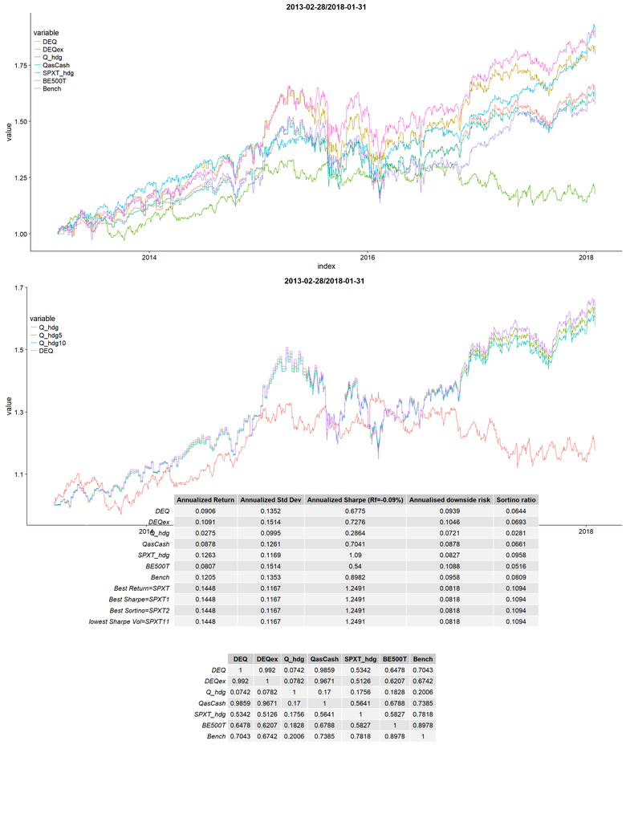

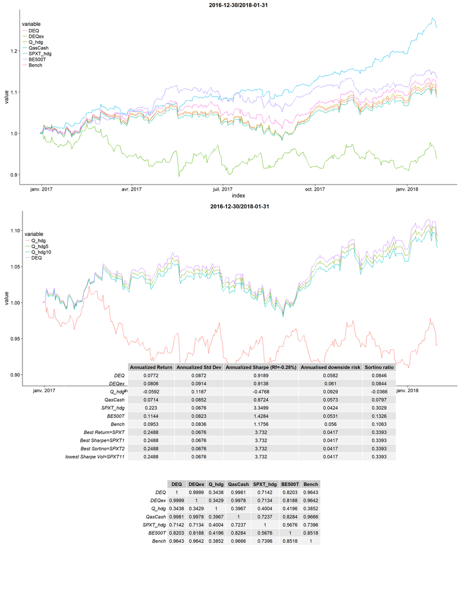

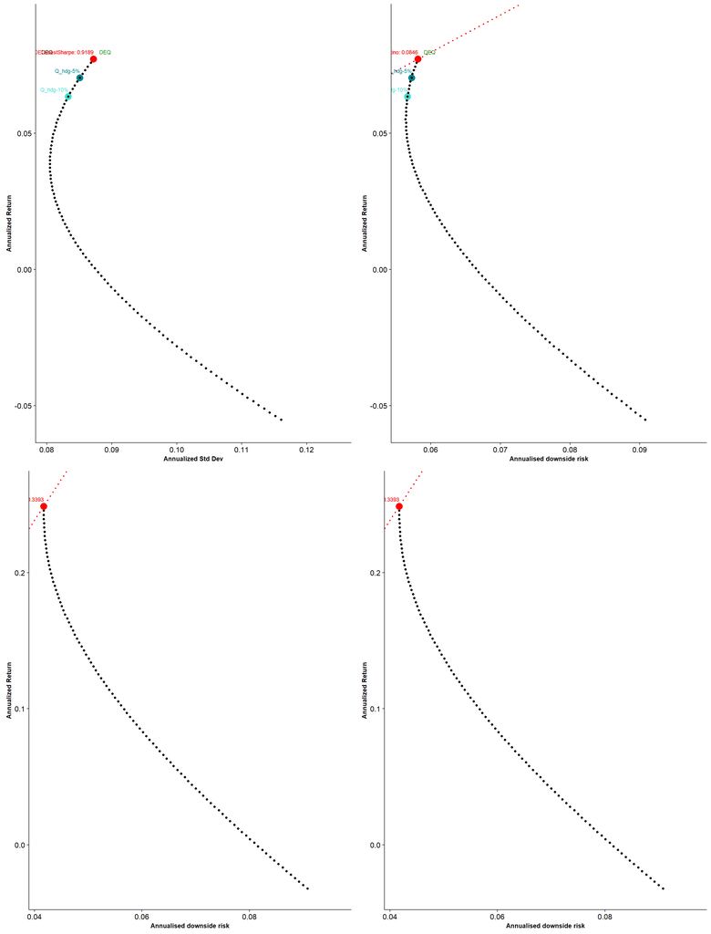